# ian branch outline

28/04/2019

### New functions

This document outlines the functions introduced to `unpivotr` by the `ian` branch on gituhub.

The `ian` branch adds two main functions.

- **`unpivotr::orientate / unpivotr::orientate_auto`** takes a tidyxl spreadsheet and adds three columns. **`.header_group`** indicates the header group to which the cell belongs, **`.orientation`** indicates whether the contents of the cell belong to a data or header section of the table. (If the cell belongs to a header section, the value of `.orientation` takes on the orientation of the header with respect to the data), **`.value`** represents the contents of the cell (This will differ from the from the valued presented in the tidyxl dataframe when the cell is part of a merge.)
- **`unpivotr::migrate`** takes the data frame produced by `unpivotr::orientate / unpivotr::orientate_auto` and converts it into a data frame with one row per data cell and one column per header.

### Example

Take the following excel table:

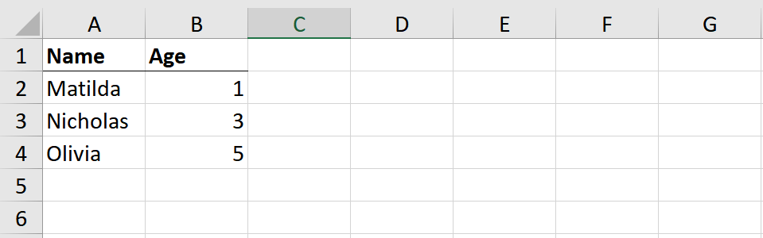

We can use `tidyxl::xlsx_cells` to read this table as a tidyxl data frame and `tidyxl::xlsx_formats` to read in its format information:

```r
# Get path to workbook.
workbook_path <- unpivotr_example("worked-examples.xlsx")

# Read in tidyxl data frame.
testsheet_df <- xlsx_cells(path = workbook_path, sheets = "clean")

# Read in formats.
format <- xlsx_formats(workbook_path)

# Show selected columns.
testsheet_df %>% select(row,col,character,numeric)
```

```
## # A tibble: 8 x 4
##     row   col character numeric
##   <int> <int> <chr>       <dbl>
## 1     1     1 Name           NA
## 2     1     2 Age            NA
## 3     2     1 Matilda        NA
## 4     2     2 <NA>            1
## 5     3     1 Nicholas       NA
## 6     3     2 <NA>            3
## 7     4     1 Olivia         NA
## 8     4     2 <NA>            5
```

**`unpivotr::orientate / unpivotr::orientate_auto`** then add **`.header_group`**, **`.orientation`** and **`.value`** variables.

**`unpivotr::orientate_auto`** detects this information automatically.

```r
# Show selected columns.
(auto_orientated_df <- testsheet_df %>% orientate_auto(formats = format) %>%
  select(row,col,character,numeric,.header_group, .orientation, .value))
```

```
## # A tibble: 8 x 7
##     row   col character numeric .header_group   .orientation .value
##   <int> <int> <chr>       <dbl> <chr>           <chr>        <chr>
## 1     1     1 Name           NA <NA>            <NA>         <NA>
## 2     1     2 Age            NA header_label_01 N            Age
## 3     2     1 Matilda        NA row_label_01    W            Matilda
## 4     2     2 <NA>            1 data            data         1
## 5     3     1 Nicholas       NA row_label_01    W            Nicholas
## 6     3     2 <NA>            3 data            data         3
## 7     4     1 Olivia         NA row_label_01    W            Olivia
## 8     4     2 <NA>            5 data            data         5
```

**`unpivotr::orientate`** takes a named string vector to add this information manually.

```r
# Create named vector indicating orientations.
orientation <- c("B2:B4"="data", "B1" = "N", "A2:A4"="W")

# Show selected columns.
(orientated_df <- testsheet_df %>% orientate(orientations = orientation) %>%
  select(row,col,character,numeric,.header_group, .orientation, .value))
```

```
## # A tibble: 8 x 7
##     row   col character numeric .header_group .orientation .value
##   <int> <int> <chr>       <dbl> <chr>         <chr>        <chr>
## 1     1     1 Name           NA <NA>          <NA>         Name
## 2     1     2 Age            NA col_label_01  N            Age
## 3     2     1 Matilda        NA row_label_02  W            Matilda
## 4     2     2 <NA>            1 row_label_01  data         1
## 5     3     1 Nicholas       NA row_label_02  W            Nicholas
## 6     3     2 <NA>            3 row_label_01  data         3
## 7     4     1 Olivia         NA row_label_02  W            Olivia
## 8     4     2 <NA>            5 row_label_01  data         5
```

**`unpivotr::migrate`** reshapes the tidyxl data frame to have one row per data cell and one column per header.

```r
# Reshape oriented dataframe.
orientated_df %>% migrate()
```

```
## # A tibble: 3 x 5
##     row   col .value col_label_01 row_label_02
##   <int> <int> <chr>  <chr>        <chr>
## 1     2     2 1      Age          Matilda
## 2     3     2 3      Age          Nicholas
## 3     4     2 5      Age          Olivia
```

```r
# Reshape auto-oriented dataframe.
auto_orientated_df %>% migrate()
```

```
## # A tibble: 3 x 5
##     row   col .value header_label_01 row_label_01
##   <int> <int> <chr>  <chr>           <chr>
## 1     2     2 1      Age             Matilda
## 2     3     2 3      Age             Nicholas
## 3     4     2 5      Age             Olivia
```

### Alternative function names

- **`orientate / orientate_auto`**
  - **`declare_directions / deduce_directions`**
  - **`direct / direct_auto`**
- **`migrate`**
  - **`enhead_all`**
  - **`enhead_enmasse`**
  - **`enhead_df`**

### More detail

- the behaviour of the **`orientate_auto`** function can be altered with the following arguments:
  - `group_col_headers_by` / `group_row_headers_by` takes a vector of strings that correspond to the formats: “indenting” “bolding” “italics” “text_color” “bg_color” “h_alignment”. Headers are grouped according to these nominated cell formats.
  - `col_header_fill` / `row_header_fill` determine how/whether blank cells in header sections of the table are delt with. Blank cells can be filled according to “local_format_id”,“style”,“borders” or “none” (not filled at all).